# Module 2 excercises

```r
library(ggplot2) #loads the ggplot functions
library(ggthemes) #themes to apply to a plot
```

Scientists use plots to present their results to others and to explore potential relationships among variables in their data. Both activities are critical for enhancing the viewers comprehension of your scientific questions and results.

| # Exercise 2A # |
| --- |

## Build a scatterplot

Plot the city mileage in the `mpg` dataset against engine size `displ` using a scatterplot.

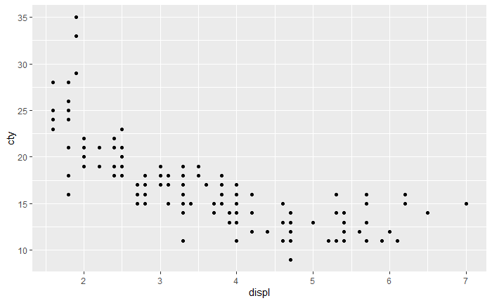

```r
#code here
ggplot(data=mpg) +
  geom_point(mapping=aes(x=displ, y=cty))
```

| # Exercise 2B # |
| --- |

## Polishing your scatterplot

Color your points by `manufacturer` and update the x- and y-axis labels to make sense for a reader.

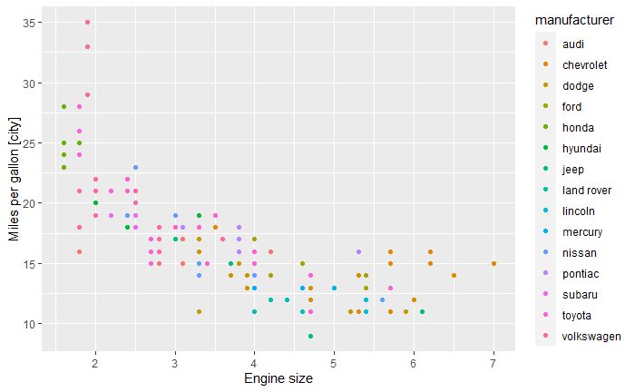

```r
#code here
ggplot(data=mpg) +
  geom_point(mapping=aes(x=displ, y=cty, col=manufacturer)) +
  xlab("Engine size") + ylab("Miles per gallon [city]")
```

| # Exercise 2C # |
| --- |

## Combining geometries

Add a `geom_smooth` with `lm` to your above plot. How well does this trendline fit the data?

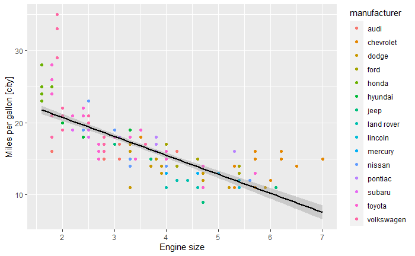

```r
#code here
ggplot(data=mpg) +
  geom_point(mapping=aes(x=displ, y=cty, col=manufacturer)) +
  xlab("Engine size") + ylab("Miles per gallon [city]") +
  geom_smooth(mapping=aes(x=displ, y=cty), method=lm, col="black")
```

### The above plot shows an approximate linear relationship between engine size and miles per gallon, though the relationship breaks down for low at high engine sizes.

| # Excercise 2D # |
| --- |

## Build a boxplot

Using the `mpg` dataset, build a boxplot of the city mileage by car manufacturer. Are there any manufacturers that appear to significantly lower than the average? How about higher than the average?

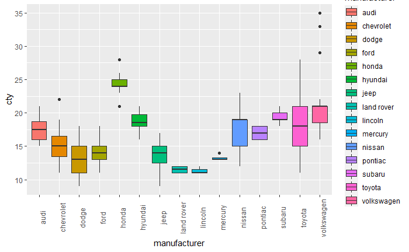

```r
#code here
ggplot(data=mpg) +
  geom_boxplot(mapping=aes(x=manufacturer, y=cty, fill=manufacturer)) +
  theme(axis.text.x = element_text(angle = 90)) #rotates axes for readability
```

### Based on the above boxplot, the manufacturers with the lowest mpg are land Rover and Lincoln, the highest average mpg (by far) is Honda.

| # Excercise 2E # |
| --- |

## Univariate plots

Build a histogram of the city mileage. Try filling by manufacturer. Now try using faceting using `facet_wrap` with `manufacturer` to illustrate difference among manufacturers. Which plot more clearly distinguishes difference among the manufacturers?

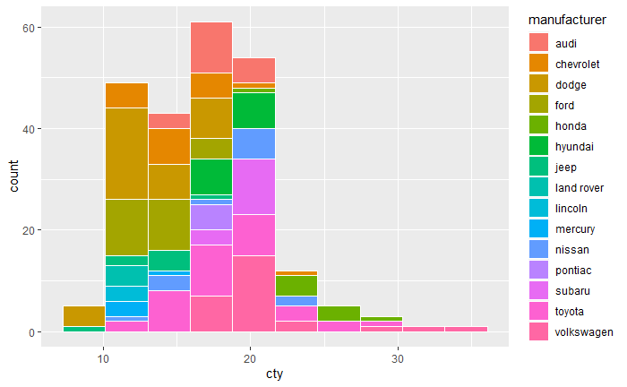

```r
#code here
ggplot(data=mpg) +
  geom_histogram(mapping=aes(x=cty, fill=manufacturer), col="white", bins=10)
```

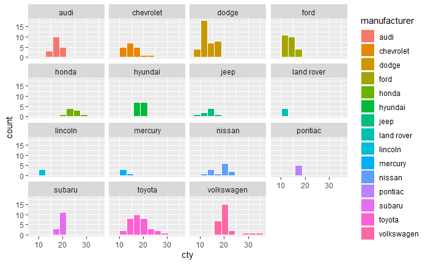

```r
ggplot(data=mpg) +
  geom_histogram(mapping=aes(x=cty, fill=manufacturer), col="white", bins=10) +
  facet_wrap(~manufacturer)
```

### Patterns are very difficult to discern using the stacked histogram The faceted histogram looks better, though I still prefer the boxplot for illustrating differences among manufacturers.

## Further refining your plots

How about modifying some aspects of your facet panels…try changing the facet layout to 3 columns and 5 rows. How might you do that? Hint: use the help file for facet_wrap.

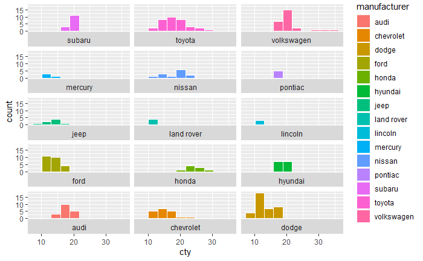

How about modifying some additional aspects of your facet panels…explore what you can do with the package ‘lemon’. Hints: first load the load the package, then figure out what options you have using the help function in R: type ‘help(lemon)’

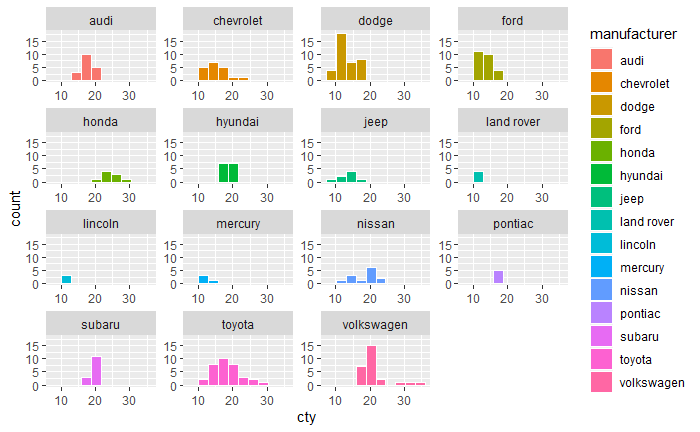